# Mixed models - cluster data

Nnamdi Joseph Asouzu

**Case study**  
Sleep deprivation: Belenky et. al. [2003] report on a study of the effects of sleep depri- vation on reaction time for a number of subjects chosen from a population of long-distance truck drivers. These subjects were divided into groups that were allowed only a limited amount of sleep each night. Each subject’s reaction time was measured several times on each day of the trial.

In this data, the response variable Reaction, is the average of the reaction time measurements on a given subject for a given day. The two covariates are Days, the number of days of sleep deprivation, and Subject, the identifier of the subject on which the observation was made.

Scientific question: Is there a relationship between reaction time and the number of days of sleep deprivation?

```r
library(lme4)
library(lattice)
library(arm)
library(car)
library(pbkrtest)
```

```r
df <- read.table(file="C:/Users/Nnamdi/Desktop/Bioinformatics/Statistical_methods_for_bioinformatics/part_I/Projects/Project6/sleep.txt", header=T)
attach(df)
df
```

|  | Reaction | Days | Subject |
| --- | --- | --- | --- |
| 1 | 249.5600 | 0 | 308 |
| 2 | 258.7047 | 1 | 308 |
| 3 | 250.8006 | 2 | 308 |
| 4 | 321.4398 | 3 | 308 |
| 5 | 356.8519 | 4 | 308 |
| 6 | 414.6901 | 5 | 308 |
| 7 | 382.2038 | 6 | 308 |
| 8 | 290.1486 | 7 | 308 |
| 9 | 430.5853 | 8 | 308 |
| 10 | 466.3535 | 9 | 308 |

[output cut: 170 more lines]

**Exploratory data analysis**

Spaghetti plot

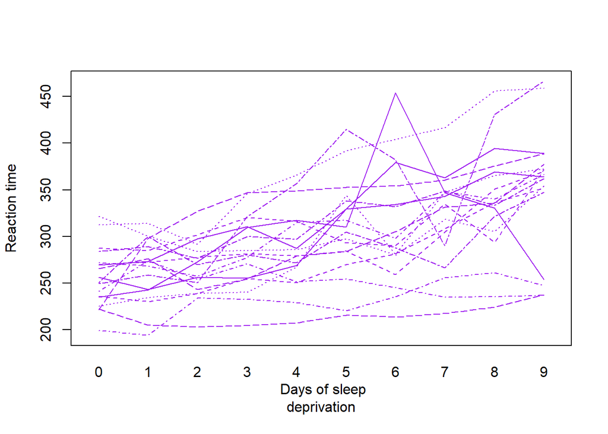

```r
n=length(unique(Subject))
interaction.plot(Days,Subject,Reaction, xlab=" Days of sleep
deprivation", ylab="Reaction time",legend=F, col = "purple")
```

The reaction time increases with increase in the number of days of sleep deprivation. Also, there is variation in the reaction time of subjects despite the increasing number of days of sleep deprivation.  
Boxplots

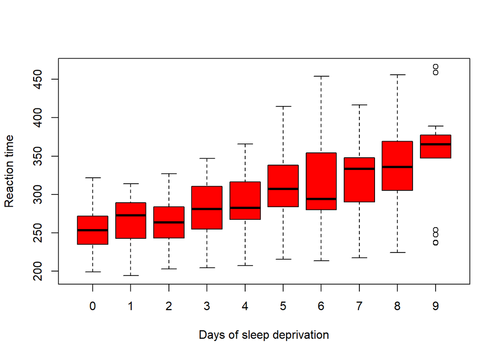

```r
boxplot(Reaction~Days,xlab="Days of sleep deprivation",ylab="Reaction time", col = "red")
```

The longer the days of sleep deprivation, the slower the reaction time of the subjects.

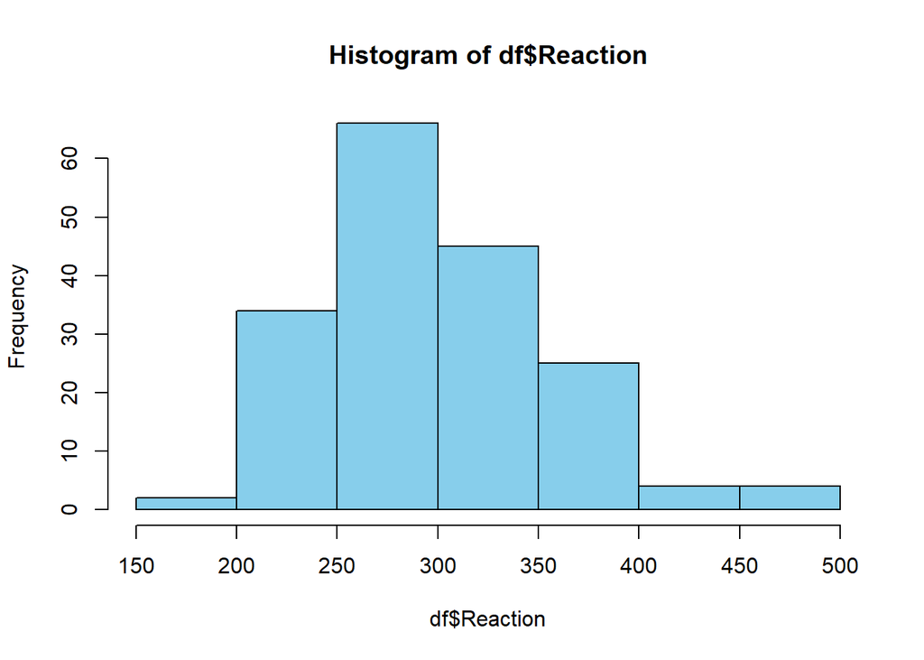

```r
hist(df$Reaction, col = "sky blue")
```

**Model fitting**

```r
df.lm <- lmer(Reaction ~ Days + (1 + Days|Subject), df, REML = FALSE)
summary(df.lm)
```

```
## Linear mixed model fit by maximum likelihood  ['lmerMod']
## Formula: Reaction ~ Days + (1 + Days | Subject)
##    Data: df
##
##      AIC      BIC   logLik deviance df.resid
##   1763.9   1783.1   -876.0   1751.9      174
##
## Scaled residuals:
##     Min      1Q  Median      3Q     Max
## -3.9416 -0.4656  0.0289  0.4636  5.1793
##
## Random effects:
##  Groups   Name        Variance Std.Dev. Corr
##  Subject  (Intercept) 565.48   23.780
##           Days         32.68    5.717   0.08
##  Residual             654.95   25.592
## Number of obs: 180, groups:  Subject, 18
##
## Fixed effects:
##             Estimate Std. Error t value
## (Intercept)  251.405      6.632  37.907
## Days          10.467      1.502   6.968
##
## Correlation of Fixed Effects:
##      (Intr)
## Days -0.138
```

Estimating fixed effect via bootstrap

```r
fixed.boot <- bootMer(df.lm, fixef, use.u=TRUE, nsim=250)
summary(fixed.boot)
```

|  | R | original | bootBias | bootSE | bootMed |
| --- | --- | --- | --- | --- | --- |
| (Intercept) | 250 | 251.40510 | 0.21642193 | 3.1862975 | 251.43777 |
| Days | 250 | 10.46729 | -0.04081876 | 0.6223849 | 10.42368 |

Calculating confidence interval for the fixed effects

```r
confint(df.lm,method="boot",boot.type ="perc",oldNames = FALSE,nsim=500)
```

```
## Computing bootstrap confidence intervals ...
```

```
##
## 20 message(s): boundary (singular) fit: see ?isSingular
## 9 warning(s): Model failed to converge with max|grad| = 0.00212939 (tol = 0.002, component 1) (and others)
```

```
##                                    2.5 %     97.5 %
## sd_(Intercept)|Subject         9.0837043  34.678034
## cor_Days.(Intercept)|Subject  -0.5019995   1.000000
## sd_Days|Subject                2.8794347   7.868904
## sigma                         22.3944711  28.722559
## (Intercept)                  238.4116899 266.213282
## Days                           7.4449690  13.428185
```

Get the KR-approximated degrees of freedom

```r
df.KR <- get_Lb_ddf(df.lm, fixef(df.lm))
early.lmer1.coef=coef(summary(df.lm))
early.lmer1.p.KR <- cbind(early.lmer1.coef,2 * (1 - pt(abs(early.lmer1.coef[,3]), df.KR)))
early.lmer1.p.KR
```

```
##              Estimate Std. Error   t value
## (Intercept) 251.40510   6.632123 37.907185 0.000000e+00
## Days         10.46729   1.502230  6.967831 1.201452e-06
```

Likelihoood ratio tests

```r
df.lm.null<-lmer(Reaction ~  (1 + Days|Subject), df, REML = FALSE)
df.lm.treat<-lmer(Reaction ~ Days + (1 + Days|Subject), df, REML = FALSE)
anova(df.lm.null,df.lm.treat)
```

|  | npar | AIC | BIC | logLik | deviance | Chisq | Df | Pr(>Chisq) |
| --- | --- | --- | --- | --- | --- | --- | --- | --- |
| df.lm.null | 5 | 1785.476 | 1801.441 | -887.7379 | 1775.476 | NA | NA | NA |
| df.lm.treat | 6 | 1763.939 | 1783.097 | -875.9697 | 1751.939 | 23.53654 | 1 | 1.22564e-06 |

The model with the treatment is significant hence the number of sleep deprived days affects reaction time.

The multimodel is given as :  
**Reaction ~ Days + (1 + Days | Subject) + e**